# SU_25_River_Rockfish_Proj_Fecundity_Ambient_VRevised

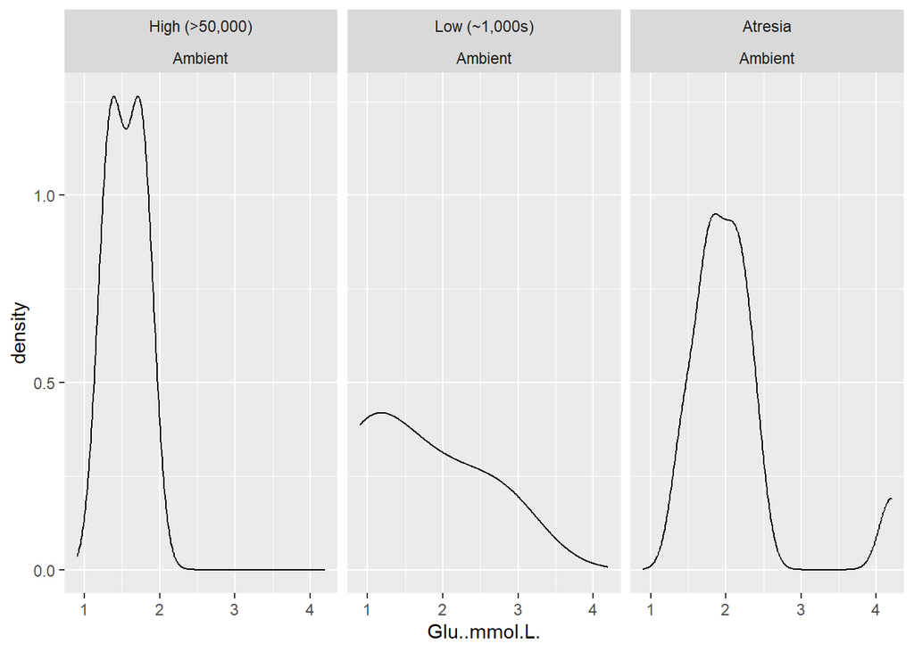

```r
ggplot(Amb_Fec_Samples, aes(x = Glu..mmol.L.)) +
  geom_density(aes(x = Glu..mmol.L.)) +
  facet_wrap(Fecundity_Class ~ Ambient.Or.OAH)
```

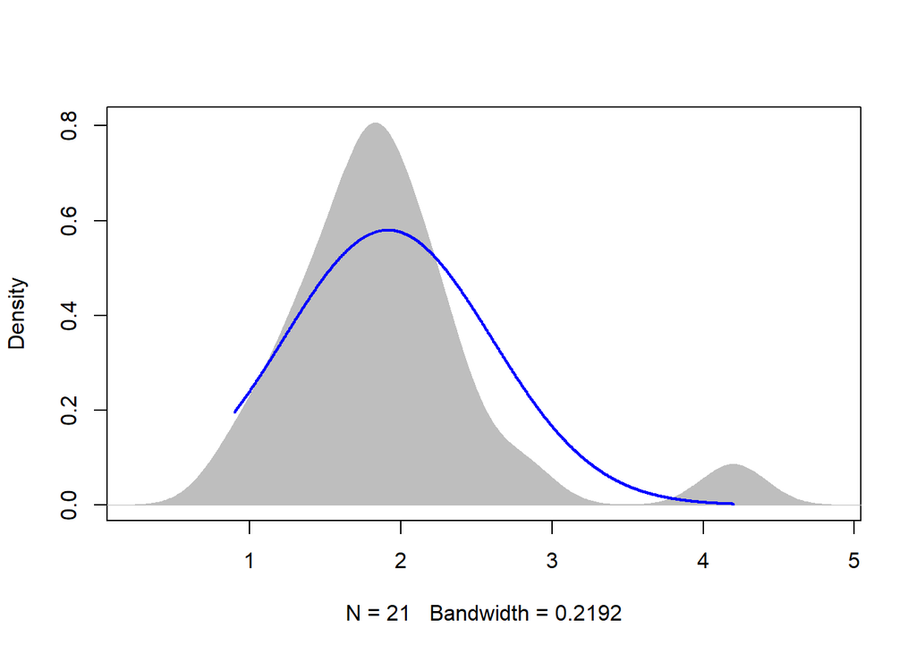

```r
plotNormalDensity(Amb_Fec_Samples$Glu..mmol.L.)
```

Test For Outliers

```r
# Test for Outliers
```

Model Design

```r
# Install flexplot
# devtools::install_github("dustinfife/flexplot", ref="development")
require(flexplot)

# Amb Fec regression model

glucose_amb_fec_lmer <- lmer(Glu..mmol.L. ~ All_Fecundity + (All_Fecundity | Fecundity_Class), data = Amb_Fec_Samples)
```

```
## boundary (singular) fit: see help('isSingular')
```

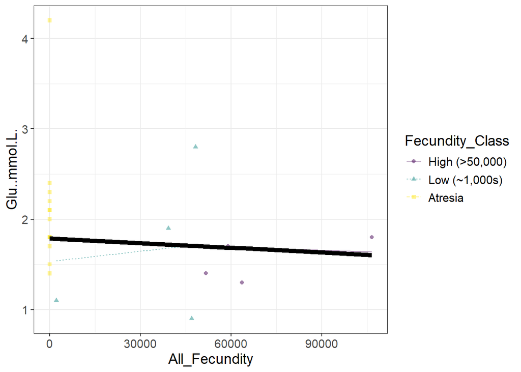

```r
visualize(glucose_amb_fec_lmer, plot = "model")
```

Glucose Normality: QQPlot and Shapiro-Wilk Test

Glucose Parametric Assessment Testing Scedasticity:

```r
# glucose

# Amb Fec samples

# test with lmer
bartlett.test(Glu..mmol.L. ~ Fecundity_Class, Amb_Fec_Samples)
```

```
##
##  Bartlett test of homogeneity of variances
##
## data:  Glu..mmol.L. by Fecundity_Class
## Bartlett's K-squared = 3.669, df = 2, p-value = 0.1597
```

```r
# leveneTest()
```

Glucose Parametric Assumptions Assessment:

Warning: Check after assessing outliers

- Amb Fec Data normally distributed?
- Amb Fec Data equal variance across factors?

# Glucose Stat Tests

# Na+ : Sodium

Sodium Summary Stats

```r
# Na+
# Summary stats

# Amb Fec data
Amb_Fec_Samples %>%
  group_by(Ambient.Or.OAH, Pregnant.Or.Atresia) %>%
  summarize(count = n(),
            median = round(median(Na...mmol.L.), 3),
            mean = round(mean(Na...mmol.L.), 3),
            sd = round(sd(Na...mmol.L.), 3),
            cv = round(sd(Na...mmol.L.)/mean(Na...mmol.L.), 3)) %>%
  ungroup()
```

```
## # A tibble: 2 × 7
##   Ambient.Or.OAH Pregnant.Or.Atresia count median  mean    sd    cv
##   <chr>          <chr>               <int>  <dbl> <dbl> <dbl> <dbl>
## 1 Ambient        Atresia                13   178   181. 11.4  0.063
## 2 Ambient        Post Parturition        8   176.  176.  3.41 0.019
```

```r
# Amb Fec Class data
Amb_Fec_Samples %>%
  group_by(Ambient.Or.OAH, Fecundity_Class) %>%
  summarize(count = n(),
            median = round(median(Na...mmol.L.), 3),
            mean = round(mean(Na...mmol.L.), 3),
            sd = round(sd(Na...mmol.L.), 3),
            cv = round(sd(Na...mmol.L.)/mean(Na...mmol.L.), 3)) %>%
  ungroup()
```

```
## # A tibble: 3 × 7
##   Ambient.Or.OAH Fecundity_Class count median  mean    sd    cv
##   <chr>          <ord>           <int>  <dbl> <dbl> <dbl> <dbl>
## 1 Ambient        High (>50,000)      4   178.  177.  2.63 0.015
## 2 Ambient        Low (~1,000s)       4   176.  175.  4.19 0.024
## 3 Ambient        Atresia            13   178   181. 11.4  0.063
```

Sodium Amb Fec Count Scatterplot

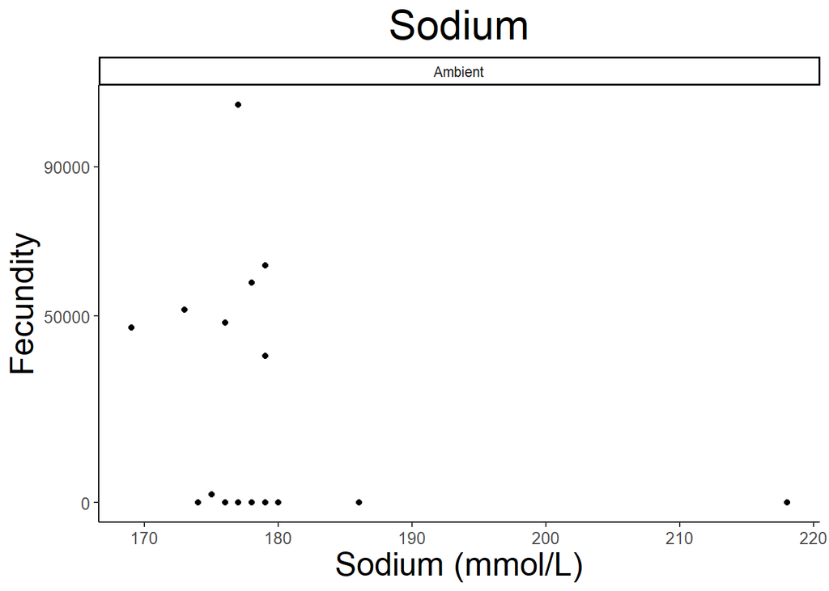

```r
# Na+ Scatterplot

# Amb_fec Samples:
# Note When using Fecundity_Or_Brood_Count col, the "No Parturition" aka atresia ids are automatically removed in plots, and results display numerical count, but this may cause issues if column is called in stat tests
# Refer to 'All_Fecundity' col (all numeric, includes atresia ids as 0)
# Refer to 'Fecundity_No_Atresia' col (all numeric, excludes atresia ids)
# Refer to 'Fecundity_Class' col for categorical classification of fecund data (Not 'Consensus_Fecundity' col, which is same, but raw data input)

# Amb Fec Count Samples : With atresia Ids
sodium_amb_fec_all_scatterplot <- ggplot(data = Amb_Fec_Samples) +
  geom_point(aes(x = Na...mmol.L., y = All_Fecundity), colour = "black") +
  labs(title = "Sodium", x = "Sodium (mmol/L)", y = "Fecundity") +
  scale_y_continuous(breaks = c(0, 50000, 90000)) +
  facet_wrap(~ Ambient.Or.OAH) +
  theme_classic() +
  theme(panel.background = element_rect(fill = "white"),
        plot.background = element_rect(fill = "white"),
        legend.background = element_rect(fill = "white", color = "black"),
        plot.title = element_text(size = 25, hjust = 0.5),
        axis.text.x = element_text(size = 10),
        axis.text.y = element_text(size = 10),
        axis.title.x = element_text(size = 20),
        axis.title.y = element_text(size = 20))

print(sodium_amb_fec_all_scatterplot)
```

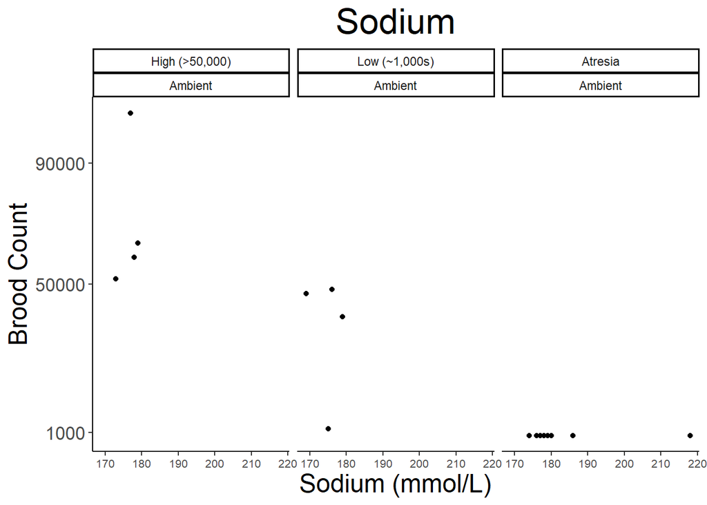

```r
ggsave(filename = "data-images/sodium_amb_fec_all_scatterplot.pdf", plot = sodium_amb_fec_all_scatterplot, device = "pdf")
ggsave(filename = "data-images/sodium_amb_fec_all_scatterplot.png", plot = sodium_amb_fec_all_scatterplot, device = "png")
# pH Amb Fec Count facet scatterplot by Fecundity Class
sodium_amb_fec_all_facet_scatterplot_fecundity_class <- ggplot(data = Amb_Fec_Samples) +
  geom_point(aes(x = Na...mmol.L., y = All_Fecundity), colour = "black") +
  labs(title = "Sodium", x = "Sodium (mmol/L)", y = "Brood Count") +
  scale_y_continuous(breaks = c(1000, 50000, 90000)) +
  facet_wrap(Fecundity_Class ~ Ambient.Or.OAH) +
  theme_classic() +
  theme(panel.background = element_rect(fill = "white"),
        plot.background = element_rect(fill = "white"),
        legend.background = element_rect(fill = "white", color = "black"),
        plot.title = element_text(size = 25, hjust = 0.5),
        axis.text.x = element_text(size = 8),
        axis.text.y = element_text(size = 13),
        axis.title.x = element_text(size = 18),
        axis.title.y = element_text(size = 18))

print(sodium_amb_fec_all_facet_scatterplot_fecundity_class)
```

Sodium Amb Fec Class Scatterplot

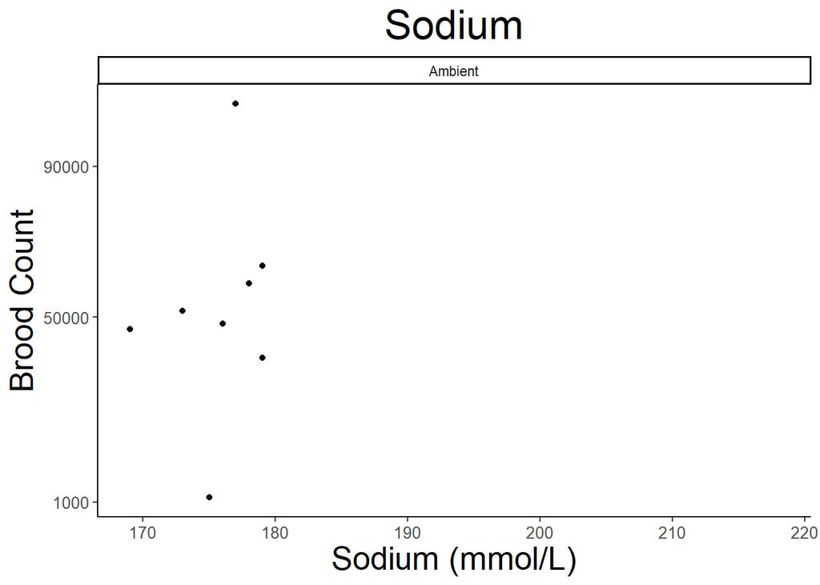

```r
# Sodium Scatterplot

# Amb_fec Samples:
# Note When using Fecundity_Or_Brood_Count col, the "No Parturition" aka atresia ids are automatically removed in plots, and results display numerical count, but this may cause issues if column is called in stat tests
# Refer to 'All_Fecundity' col (all numeric, includes atresia ids as 0)
# Refer to 'Fecundity_No_Atresia' col (all numeric, excludes atresia ids)
# Refer to 'Fecundity_Class' col for categorical classification of fecund data (Not 'Consensus_Fecundity' col, which is same, but raw data input)

# Amb Fec only scatterplot: atresia ids removed
sodium_amb_fec_no_atresia_scatterplot <- ggplot(data = Amb_Fec_Samples) +
  geom_point(aes(x = Na...mmol.L., y = Fecundity_No_Atresia), colour = "black") +
  labs(title = "Sodium", x = "Sodium (mmol/L)", y = "Brood Count") +
  scale_y_continuous(breaks = c(1000, 50000, 90000)) +
  theme_classic() +
  facet_wrap(~ Ambient.Or.OAH) +
  theme(panel.background = element_rect(fill = "white"),
        plot.background = element_rect(fill = "white"),
        legend.background = element_rect(fill = "white", color = "black"),
        plot.title = element_text(size = 25, hjust = 0.5),
        axis.text.x = element_text(size = 10),
        axis.text.y = element_text(size = 10),
        axis.title.x = element_text(size = 20),
        axis.title.y = element_text(size = 20))

print(sodium_amb_fec_no_atresia_scatterplot)
```

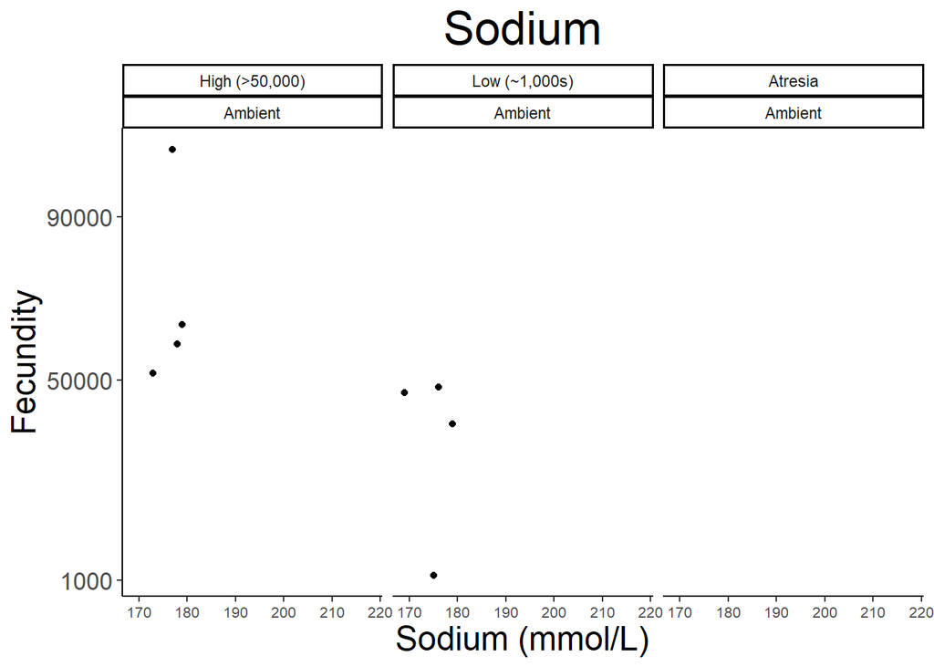

```r
ggsave(filename = "data-images/sodium_amb_fec_no_atresia_scatterplot.pdf", plot = sodium_amb_fec_no_atresia_scatterplot, device = "pdf")
ggsave(filename = "data-images/sodium_amb_fec_no_atresia_scatterplot.png", plot = sodium_amb_fec_no_atresia_scatterplot, device = "png")
# pH Amb Fec No Atresia facet scatterplot by Fecundity Class
pH_amb_fec_no_atresia_facet_scatterplot_fecundity_class <- ggplot(data = Amb_Fec_Samples) +
  geom_point(aes(x = Na...mmol.L., y = Fecundity_No_Atresia), colour = "black") +
  labs(title = "Sodium", x = "Sodium (mmol/L)", y = "Fecundity") +
  scale_y_continuous(breaks = c(1000, 50000, 90000)) +
  facet_wrap(Fecundity_Class ~ Ambient.Or.OAH) +
  theme_classic() +
  theme(panel.background = element_rect(fill = "white"),
        plot.background = element_rect(fill = "white"),
        legend.background = element_rect(fill = "white", color = "black"),
        plot.title = element_text(size = 25, hjust = 0.5),
        axis.text.x = element_text(size = 8),
        axis.text.y = element_text(size = 13),
        axis.title.x = element_text(size = 18),
        axis.title.y = element_text(size = 18))


print(pH_amb_fec_no_atresia_facet_scatterplot_fecundity_class)
```

Sodium Boxplot

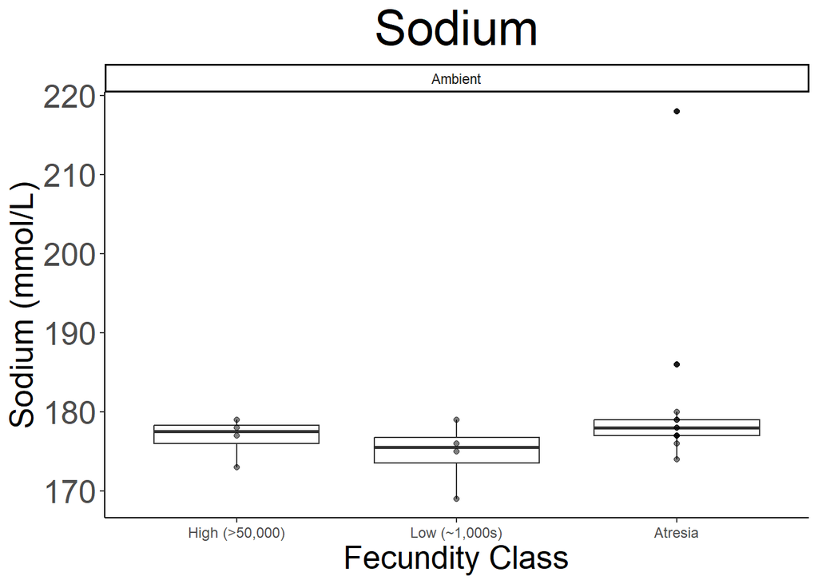

```r
# Na+ boxplot

# Amb_Fec Samples with Atresia Ids
sodium_amb_fec_boxplot <- ggplot(data = Amb_Fec_Samples) +
  geom_boxplot(aes(x = Fecundity_Class, y = Na...mmol.L.)) +
  geom_point(aes(x = Fecundity_Class, y = Na...mmol.L.), alpha = 0.5, colour = "black") +
  labs(title = "Sodium", x = "Fecundity Class", y = "Sodium (mmol/L)") +
   facet_wrap(~ Ambient.Or.OAH) +
  theme_classic() +
  theme(panel.background = element_rect(fill = "white"),
        plot.background = element_rect(fill = "white"),
        legend.background = element_rect(fill = "white", color = "black"),
        title = element_text(size = 12),
        plot.title = element_text(size = 30, hjust = 0.5),
        axis.text.x = element_text(size = 9),
        axis.text.y = element_text(size = 20),
        axis.title.x = element_text(size = 20),
        axis.title.y = element_text(size = 20))

print(sodium_amb_fec_boxplot)
```

```r
ggsave(filename = "data-images/sodium_amb_fec_boxplot.pdf", plot = sodium_amb_fec_boxplot, device = "pdf")
ggsave(filename = "data-images/sodium_amb_fec_boxplot.png", plot = sodium_amb_fec_boxplot, device = "png")
```

Sodium Parametric Assessment Data Distribution

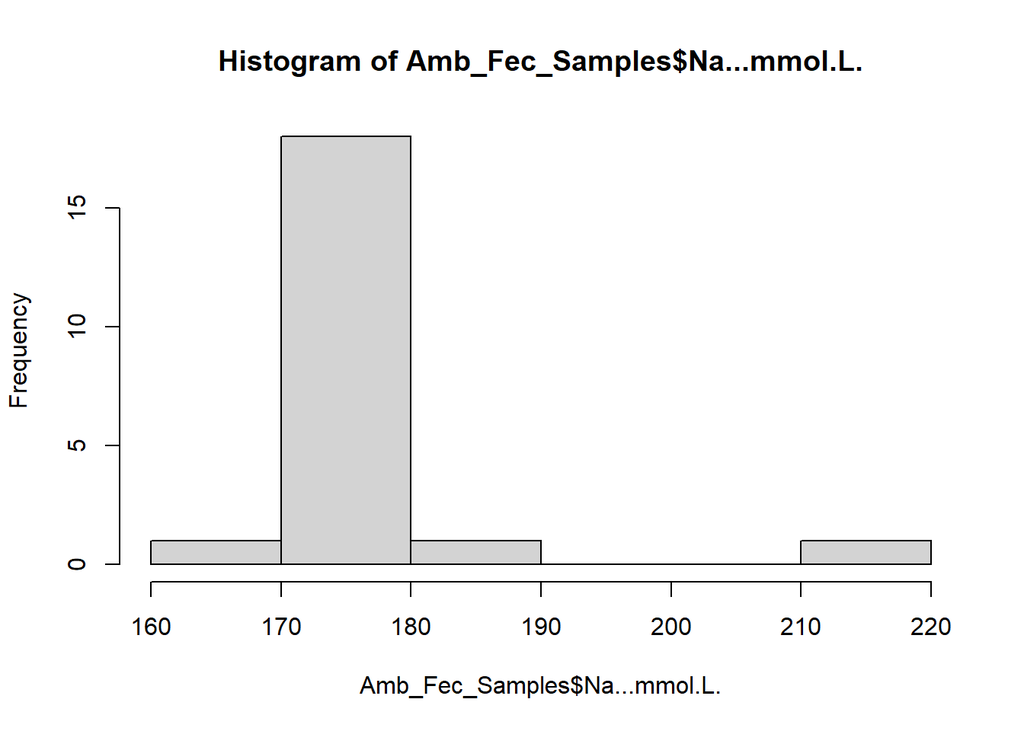

```r
# Na+
# Parametric Assumptions

# Data Distribution


# Amb Fec Samples
# Frequency Histograms

hist(Amb_Fec_Samples$Na...mmol.L.)
```

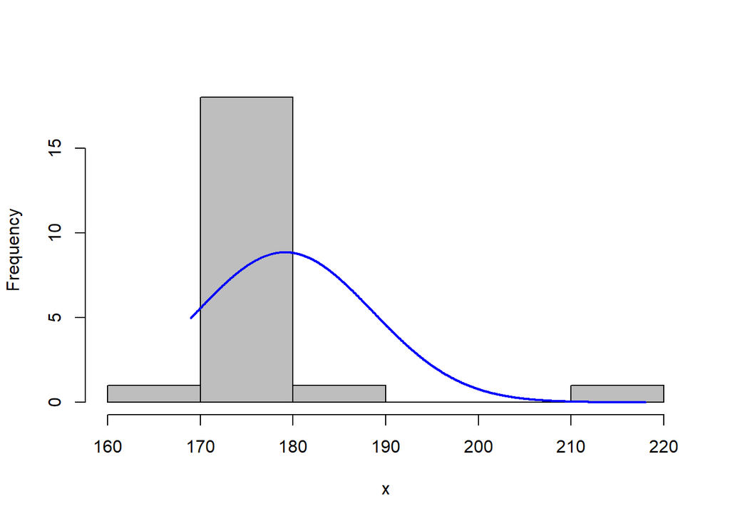

```r
plotNormalHistogram(Amb_Fec_Samples$Na...mmol.L.)
```

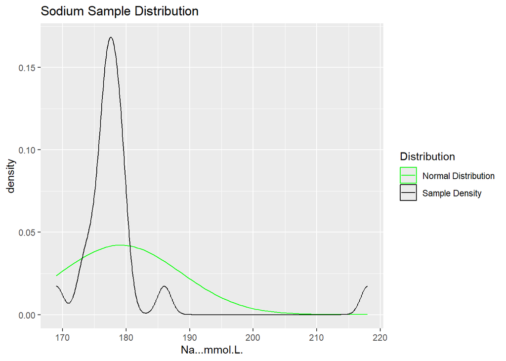

```r
# Density plot

Amb_Fec_Samples %>%
  ggplot(aes(x = Na...mmol.L.)) +
  stat_function(fun = dnorm, args = c(mean = mean(Amb_Fec_Samples$Na...mmol.L.), sd = sd(Amb_Fec_Samples$Na...mmol.L.)), aes(col = "Normal Distribution"), show.legend = TRUE) +
  geom_density(aes(col = "Sample Density"), show.legend = TRUE) +
  labs(title = "Sodium Sample Distribution") +
  scale_color_manual("Distribution", values = c("Normal Distribution" = "green", "Sample Density" = "black"))
```

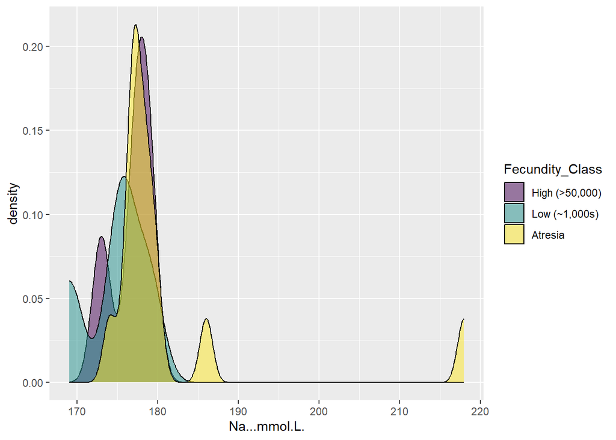

```r
# Density by brood condition
Amb_Fec_Samples %>%
ggplot(aes(x = Na...mmol.L.)) +
  geom_density(aes(x = Na...mmol.L., fill = Fecundity_Class), alpha = 0.5)
```

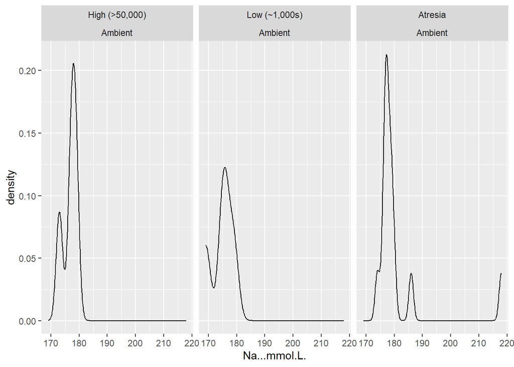

```r
ggplot(Amb_Fec_Samples, aes(x = Na...mmol.L.)) +
  geom_density(aes(x = Na...mmol.L.)) +
  facet_wrap(Fecundity_Class ~ Ambient.Or.OAH)
```

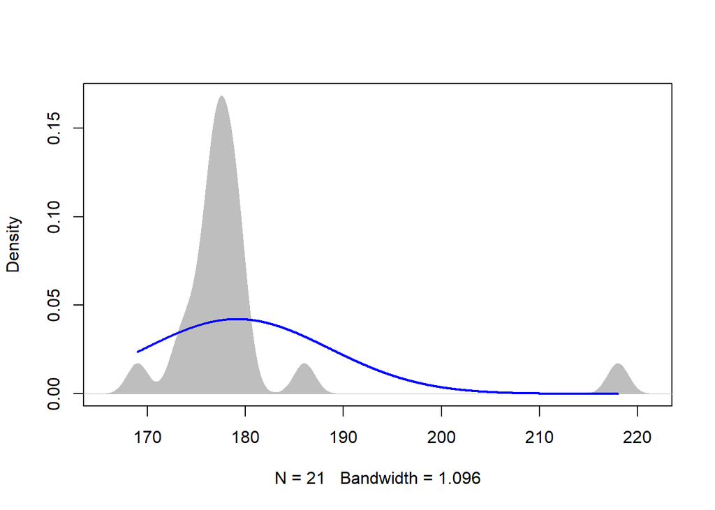

```r
plotNormalDensity(Amb_Fec_Samples$Na...mmol.L.)
```

Test For Outliers

```r
# Test for Outliers
```

Model Design

```r
# Install flexplot
# devtools::install_github("dustinfife/flexplot", ref="development")
require(flexplot)

# Amb Fec regression model

sodium_amb_fec_lmer <- lmer(Na...mmol.L. ~ All_Fecundity + (All_Fecundity | Fecundity_Class), data = Amb_Fec_Samples)
```

```
## boundary (singular) fit: see help('isSingular')
```

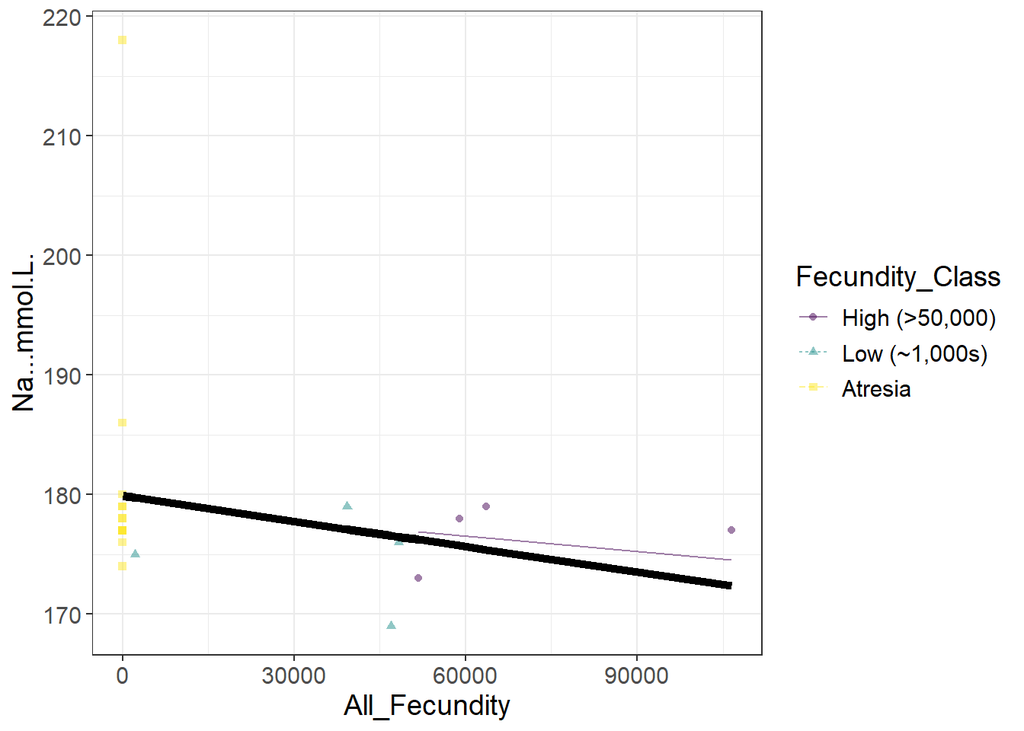

```r
visualize(sodium_amb_fec_lmer, plot = "model")
```

Sodium Normality: QQPlot and Shapiro-Wilk Test

Sodium Parametric Assessment Testing Scedasticity:

```r
# Sodium

# Amb Fec samples

# test with lmer
bartlett.test(Na...mmol.L. ~ Fecundity_Class, Amb_Fec_Samples)
```

```
##
##  Bartlett test of homogeneity of variances
##
## data:  Na...mmol.L. by Fecundity_Class
## Bartlett's K-squared = 7.4634, df = 2, p-value = 0.02395
```

```r
# leveneTest()
```

Sodium Parametric Assumptions Assessment:

Warning: Check after assessing outliers

- Amb Fec Data normally distributed?
- Amb Fec Data equal variance across factors?

# Na+ Stat Tests

# Cl- : Chloride

Chloride Summary Stats

```r
# Cl-
# Summary stats

# Amb Fec data
Amb_Fec_Samples %>%
  group_by(Ambient.Or.OAH, Pregnant.Or.Atresia) %>%
  summarize(count = n(),
            median = round(median(Cl...mmol.L.), 3),
            mean = round(mean(Cl...mmol.L.), 3),
            sd = round(sd(Cl...mmol.L.), 3),
            cv = round(sd(Cl...mmol.L.)/mean(Cl...mmol.L.), 3)) %>%
  ungroup()
```

```
## # A tibble: 2 × 7
##   Ambient.Or.OAH Pregnant.Or.Atresia count median  mean    sd    cv
##   <chr>          <chr>               <int>  <dbl> <dbl> <dbl> <dbl>
## 1 Ambient        Atresia                13    158  158.  4.61 0.029
## 2 Ambient        Post Parturition        8    157  158.  3.10 0.02
```

```r
# Amb Fec Class data
Amb_Fec_Samples %>%
  group_by(Ambient.Or.OAH, Fecundity_Class) %>%
  summarize(count = n(),
            median = round(median(Cl...mmol.L.), 3),
            mean = round(mean(Cl...mmol.L.), 3),
            sd = round(sd(Cl...mmol.L.), 3),
            cv = round(sd(Cl...mmol.L.)/mean(Cl...mmol.L.), 3)) %>%
  ungroup()
```

```
## # A tibble: 3 × 7
##   Ambient.Or.OAH Fecundity_Class count median  mean    sd    cv
##   <chr>          <ord>           <int>  <dbl> <dbl> <dbl> <dbl>
## 1 Ambient        High (>50,000)      4   158.  158   2.94 0.019
## 2 Ambient        Low (~1,000s)       4   156   158.  3.70 0.023
## 3 Ambient        Atresia            13   158   158.  4.61 0.029
```

Chloride Amb Fec Count Scatterplot

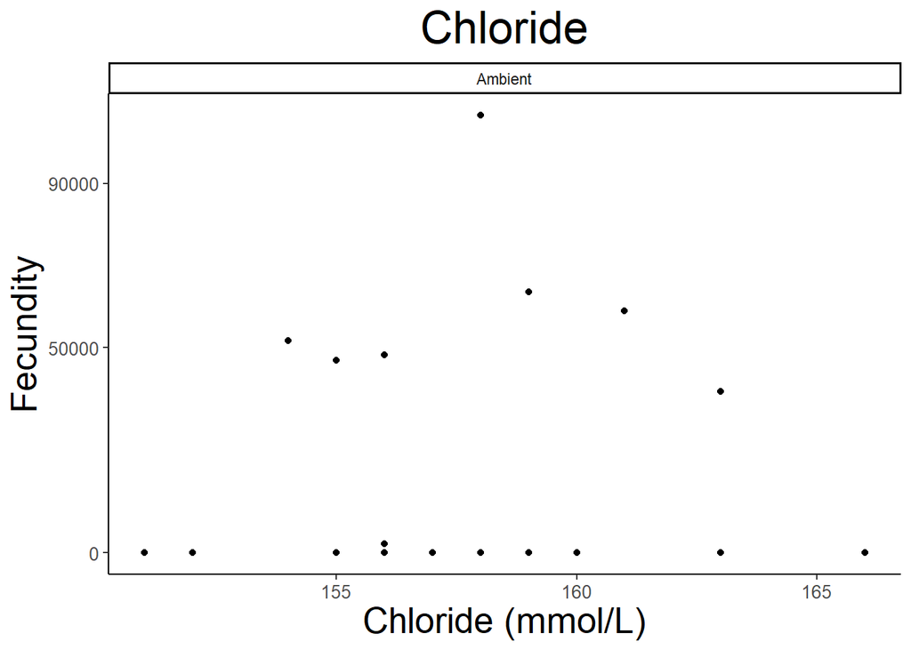

```r
# Cl- Scatterplot

# Amb_fec Samples:
# Note When using Fecundity_Or_Brood_Count col, the "No Parturition" aka atresia ids are automatically removed in plots, and results display numerical count, but this may cause issues if column is called in stat tests
# Refer to 'All_Fecundity' col (all numeric, includes atresia ids as 0)
# Refer to 'Fecundity_No_Atresia' col (all numeric, excludes atresia ids)
# Refer to 'Fecundity_Class' col for categorical classification of fecund data (Not 'Consensus_Fecundity' col, which is same, but raw data input)

# Amb Fec Count Samples : With atresia Ids
chloride_amb_fec_all_scatterplot <- ggplot(data = Amb_Fec_Samples) +
  geom_point(aes(x = Cl...mmol.L., y = All_Fecundity), colour = "black") +
  labs(title = "Chloride", x = "Chloride (mmol/L)", y = "Fecundity") +
  scale_y_continuous(breaks = c(0, 50000, 90000)) +
  facet_wrap(~ Ambient.Or.OAH) +
  theme_classic() +
  theme(panel.background = element_rect(fill = "white"),
        plot.background = element_rect(fill = "white"),
        legend.background = element_rect(fill = "white", color = "black"),
        plot.title = element_text(size = 25, hjust = 0.5),
        axis.text.x = element_text(size = 10),
        axis.text.y = element_text(size = 10),
        axis.title.x = element_text(size = 20),
        axis.title.y = element_text(size = 20))

print(chloride_amb_fec_all_scatterplot)
```

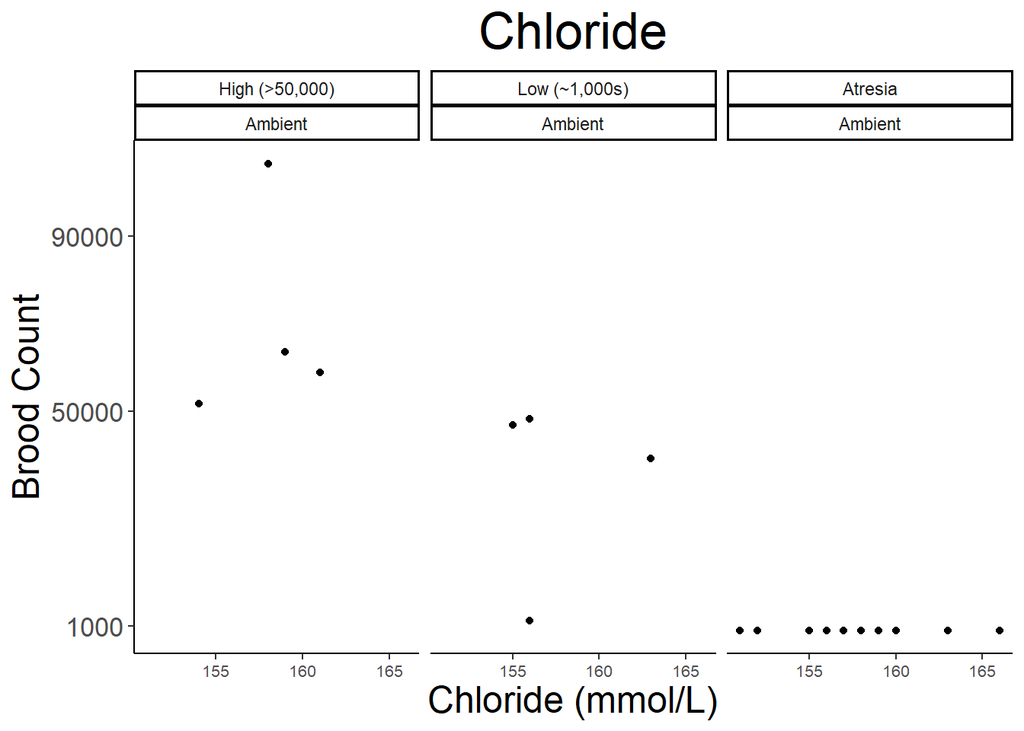

```r
ggsave(filename = "data-images/chloride_amb_fec_all_scatterplot.pdf", plot = chloride_amb_fec_all_scatterplot, device = "pdf")
ggsave(filename = "data-images/chloride_amb_fec_all_scatterplot.png", plot = chloride_amb_fec_all_scatterplot, device = "png")
# pH Amb Fec Count facet scatterplot by Fecundity Class
chloride_amb_fec_all_facet_scatterplot_fecundity_class <- ggplot(data = Amb_Fec_Samples) +
  geom_point(aes(x = Cl...mmol.L., y = All_Fecundity), colour = "black") +
  labs(title = "Chloride", x = "Chloride (mmol/L)", y = "Brood Count") +
  scale_y_continuous(breaks = c(1000, 50000, 90000)) +
  facet_wrap(Fecundity_Class ~ Ambient.Or.OAH) +
  theme_classic() +
  theme(panel.background = element_rect(fill = "white"),
        plot.background = element_rect(fill = "white"),
        legend.background = element_rect(fill = "white", color = "black"),
        plot.title = element_text(size = 25, hjust = 0.5),
        axis.text.x = element_text(size = 8),
        axis.text.y = element_text(size = 13),
        axis.title.x = element_text(size = 18),
        axis.title.y = element_text(size = 18))

print(chloride_amb_fec_all_facet_scatterplot_fecundity_class)
```

Chloride Boxplot

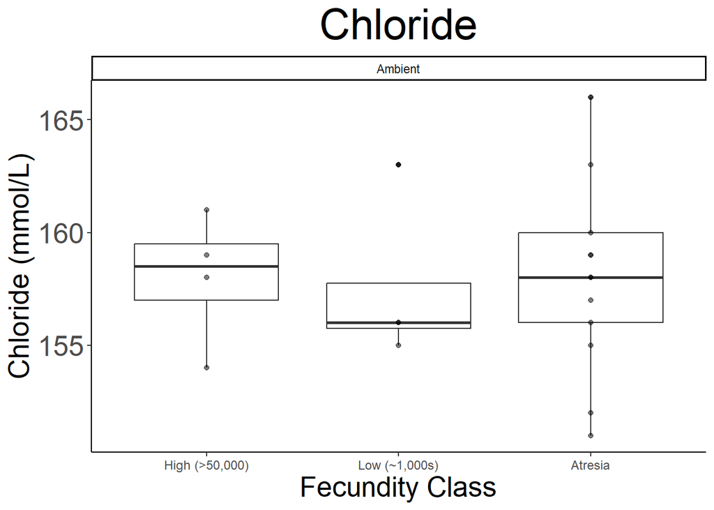

```r
# Cl- boxplot

# Amb_Fec Samples with Atresia Ids
chloride_amb_fec_boxplot <- ggplot(data = Amb_Fec_Samples) +
  geom_boxplot(aes(x = Fecundity_Class, y = Cl...mmol.L.)) +
  geom_point(aes(x = Fecundity_Class, y = Cl...mmol.L.), alpha = 0.5, colour = "black") +
  labs(title = "Chloride", x = "Fecundity Class", y = "Chloride (mmol/L)") +
   facet_wrap(~ Ambient.Or.OAH) +
  theme_classic() +
  theme(panel.background = element_rect(fill = "white"),
        plot.background = element_rect(fill = "white"),
        legend.background = element_rect(fill = "white", color = "black"),
        title = element_text(size = 12),
        plot.title = element_text(size = 30, hjust = 0.5),
        axis.text.x = element_text(size = 9),
        axis.text.y = element_text(size = 20),
        axis.title.x = element_text(size = 20),
        axis.title.y = element_text(size = 20))

print(chloride_amb_fec_boxplot)
```

```r
ggsave(filename = "data-images/chloride_amb_fec_boxplot.pdf", plot = chloride_amb_fec_boxplot, device = "pdf")
ggsave(filename = "data-images/chloride_amb_fec_boxplot.png", plot = chloride_amb_fec_boxplot, device = "png")
```

Chloride Parametric Assessment Data Distribution

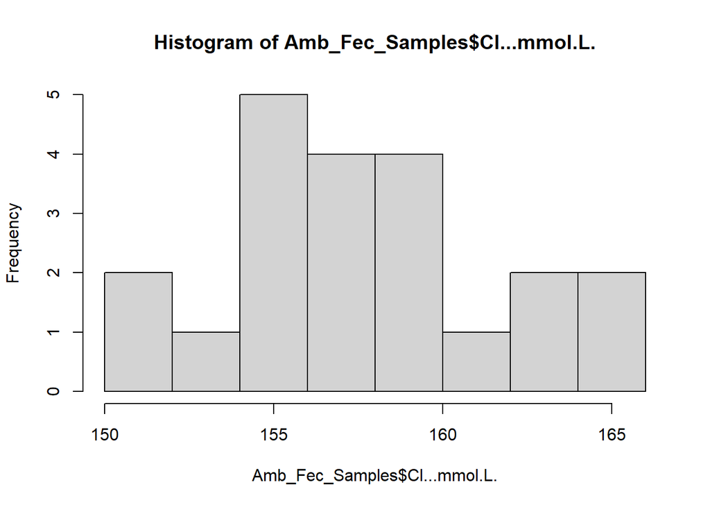

```r
# Cl-
# Parametric Assumptions

# Data Distribution


# Amb Fec Samples
# Frequency Histograms

hist(Amb_Fec_Samples$Cl...mmol.L.)
```

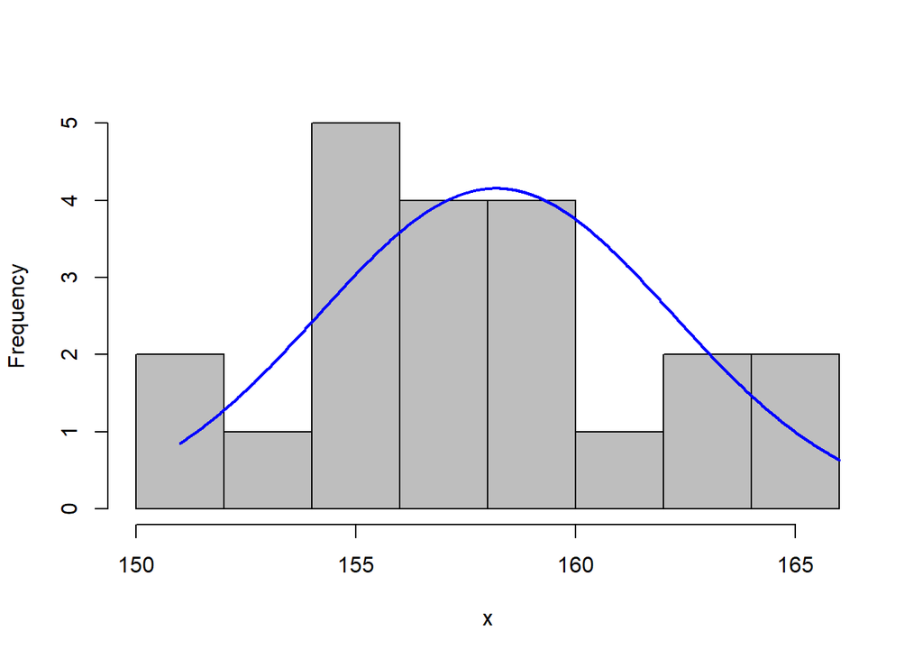

```r
plotNormalHistogram(Amb_Fec_Samples$Cl...mmol.L.)
```

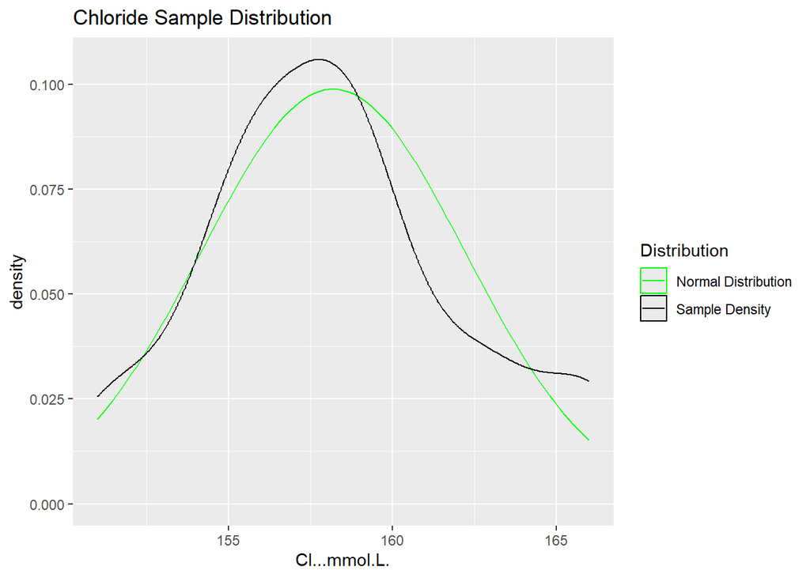

```r
# Density plot

Amb_Fec_Samples %>%
  ggplot(aes(x = Cl...mmol.L.)) +
  stat_function(fun = dnorm, args = c(mean = mean(Amb_Fec_Samples$Cl...mmol.L.), sd = sd(Amb_Fec_Samples$Cl...mmol.L.)), aes(col = "Normal Distribution"), show.legend = TRUE) +
  geom_density(aes(col = "Sample Density"), show.legend = TRUE) +
  labs(title = "Chloride Sample Distribution") +
  scale_color_manual("Distribution", values = c("Normal Distribution" = "green", "Sample Density" = "black"))
```

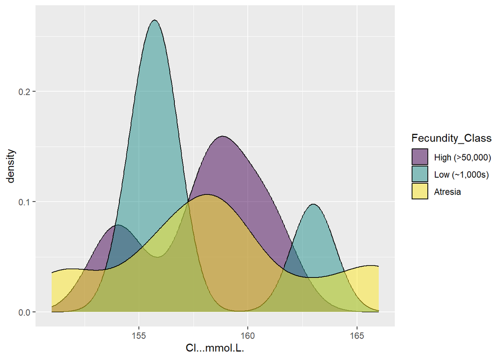

```r
# Density by brood condition
Amb_Fec_Samples %>%
ggplot(aes(x = Cl...mmol.L.)) +
  geom_density(aes(x = Cl...mmol.L., fill = Fecundity_Class), alpha = 0.5)
```

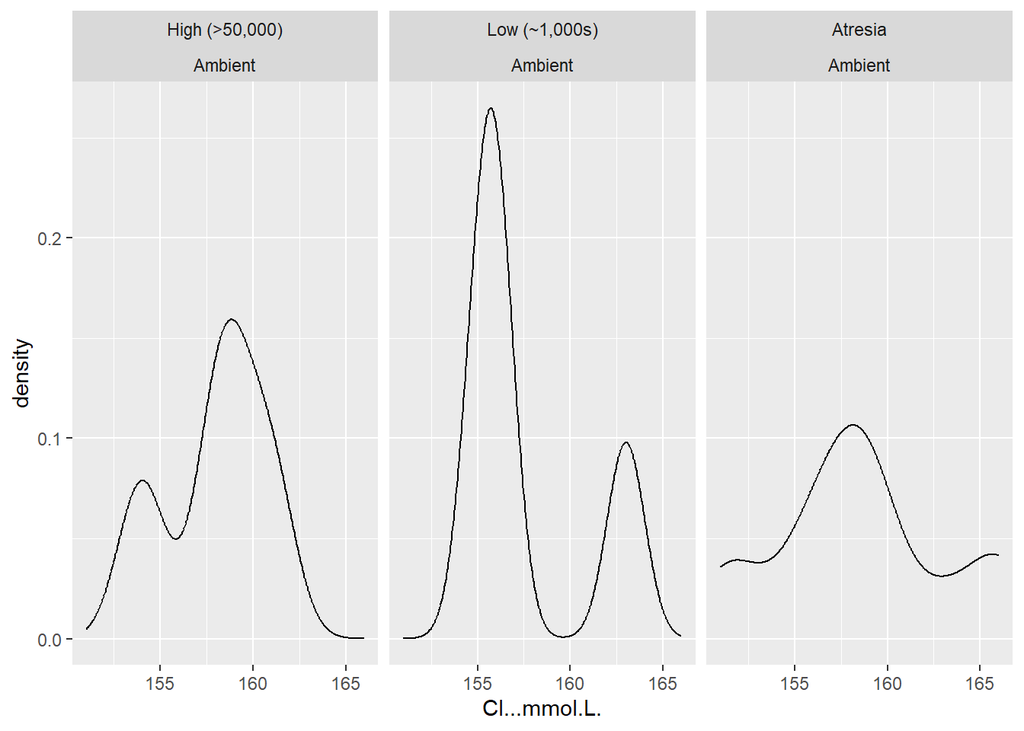

```r
ggplot(Amb_Fec_Samples, aes(x = Cl...mmol.L.)) +
  geom_density(aes(x = Cl...mmol.L.)) +
  facet_wrap(Fecundity_Class ~ Ambient.Or.OAH)
```

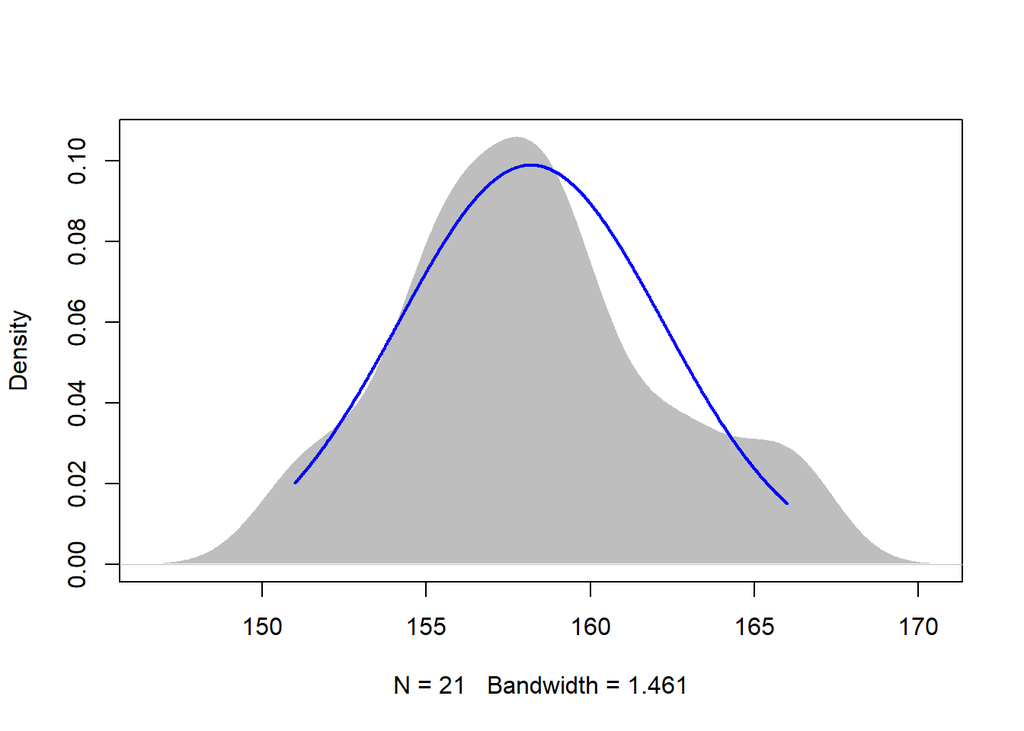

```r
plotNormalDensity(Amb_Fec_Samples$Cl...mmol.L.)
```

Test For Outliers

```r
# Test for Outliers
```

Model Design

```r
# Install flexplot
# devtools::install_github("dustinfife/flexplot", ref="development")
require(flexplot)

# Amb Fec regression model

chloride_amb_fec_lmer <- lmer(Cl...mmol.L. ~ All_Fecundity + (All_Fecundity | Fecundity_Class), data = Amb_Fec_Samples)
```

```
## boundary (singular) fit: see help('isSingular')
```

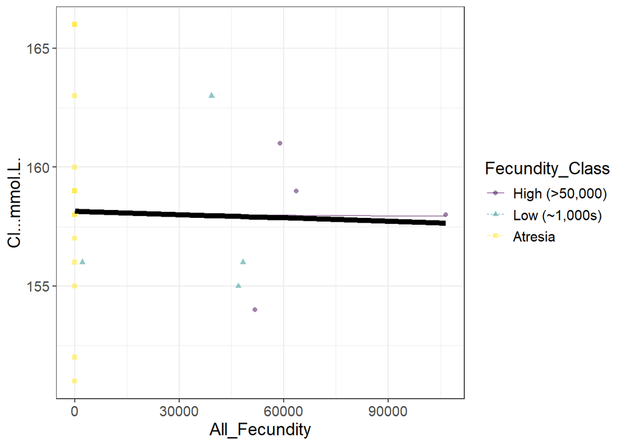

```r
visualize(chloride_amb_fec_lmer, plot = "model")
```

Chloride Normality: QQPlot and Shapiro-Wilk Test

Chloride Parametric Assessment Testing Scedasticity:

```r
# Cl-

# Amb Fec samples

# test with lmer
bartlett.test(Cl...mmol.L. ~ Fecundity_Class, Amb_Fec_Samples)
```

```
##
##  Bartlett test of homogeneity of variances
##
## data:  Cl...mmol.L. by Fecundity_Class
## Bartlett's K-squared = 0.82247, df = 2, p-value = 0.6628
```

```r
# leveneTest()
```

Chloride Parametric Assumptions Assessment:

Warning: Check after assessing outliers

- Amb Fec Data normally distributed?
- Amb Fec Data equal variance across factors?

# Cl- Stat Tests

# K : Potassium

Potassium Summary Stats

```r
# K+
# Summary stats

# Amb Fec data
Amb_Fec_Samples %>%
  group_by(Ambient.Or.OAH, Pregnant.Or.Atresia) %>%
  summarize(count = n(),
            median = round(median(K...mmol.L.), 3),
            mean = round(mean(K...mmol.L.), 3),
            sd = round(sd(K...mmol.L.), 3),
            cv = round(sd(K...mmol.L.)/mean(K...mmol.L.), 3)) %>%
  ungroup()
```

```
## # A tibble: 2 × 7
##   Ambient.Or.OAH Pregnant.Or.Atresia count median  mean    sd    cv
##   <chr>          <chr>               <int>  <dbl> <dbl> <dbl> <dbl>
## 1 Ambient        Atresia                13    2.7  2.86 0.304 0.106
## 2 Ambient        Post Parturition        8    2.7  2.71 0.146 0.054
```

```r
# Amb Fec Class data
Amb_Fec_Samples %>%
  group_by(Ambient.Or.OAH, Fecundity_Class) %>%
  summarize(count = n(),
            median = round(median(K...mmol.L.), 3),
            mean = round(mean(K...mmol.L.), 3),
            sd = round(sd(K...mmol.L.), 3),
            cv = round(sd(K...mmol.L.)/mean(K...mmol.L.), 3)) %>%
  ungroup()
```

```
## # A tibble: 3 × 7
##   Ambient.Or.OAH Fecundity_Class count median  mean    sd    cv
##   <chr>          <ord>           <int>  <dbl> <dbl> <dbl> <dbl>
## 1 Ambient        High (>50,000)      4    2.7  2.7  0.082 0.03
## 2 Ambient        Low (~1,000s)       4    2.7  2.72 0.206 0.076
## 3 Ambient        Atresia            13    2.7  2.86 0.304 0.106
```

Potassium Amb Fec Count Scatterplot

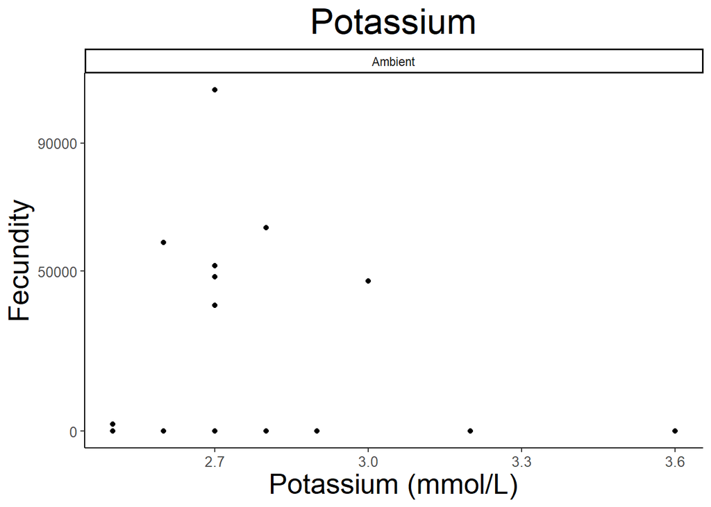

```r
# K+ Scatterplot

# Amb_fec Samples:
# Note When using Fecundity_Or_Brood_Count col, the "No Parturition" aka atresia ids are automatically removed in plots, and results display numerical count, but this may cause issues if column is called in stat tests
# Refer to 'All_Fecundity' col (all numeric, includes atresia ids as 0)
# Refer to 'Fecundity_No_Atresia' col (all numeric, excludes atresia ids)
# Refer to 'Fecundity_Class' col for categorical classification of fecund data (Not 'Consensus_Fecundity' col, which is same, but raw data input)

# Amb Fec Count Samples : With atresia Ids
potassium_amb_fec_all_scatterplot <- ggplot(data = Amb_Fec_Samples) +
  geom_point(aes(x = K...mmol.L., y = All_Fecundity), colour = "black") +
  labs(title = "Potassium", x = "Potassium (mmol/L)", y = "Fecundity") +
  scale_y_continuous(breaks = c(0, 50000, 90000)) +
  facet_wrap(~ Ambient.Or.OAH) +
  theme_classic() +
  theme(panel.background = element_rect(fill = "white"),
        plot.background = element_rect(fill = "white"),
        legend.background = element_rect(fill = "white", color = "black"),
        plot.title = element_text(size = 25, hjust = 0.5),
        axis.text.x = element_text(size = 10),
        axis.text.y = element_text(size = 10),
        axis.title.x = element_text(size = 20),
        axis.title.y = element_text(size = 20))

print(potassium_amb_fec_all_scatterplot)
```

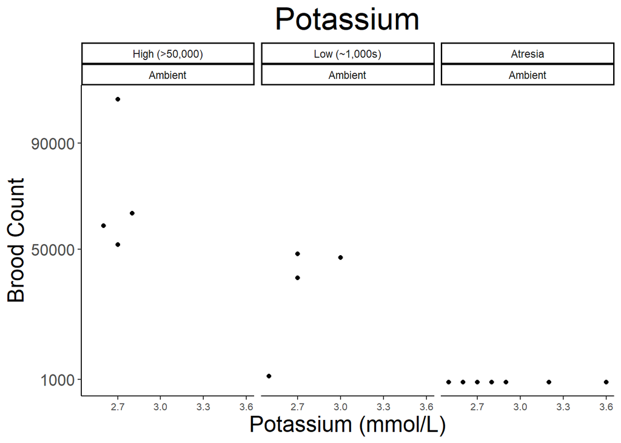

```r
ggsave(filename = "data-images/potassium_amb_fec_all_scatterplot.pdf", plot = potassium_amb_fec_all_scatterplot, device = "pdf")
ggsave(filename = "data-images/potassium_amb_fec_all_scatterplot.png", plot = potassium_amb_fec_all_scatterplot, device = "png")
# pH Amb Fec Count facet scatterplot by Fecundity Class
potassium_amb_fec_all_facet_scatterplot_fecundity_class <- ggplot(data = Amb_Fec_Samples) +
  geom_point(aes(x = K...mmol.L., y = All_Fecundity), colour = "black") +
  labs(title = "Potassium", x = "Potassium (mmol/L)", y = "Brood Count") +
  scale_y_continuous(breaks = c(1000, 50000, 90000)) +
  facet_wrap(Fecundity_Class ~ Ambient.Or.OAH) +
  theme_classic() +
  theme(panel.background = element_rect(fill = "white"),
        plot.background = element_rect(fill = "white"),
        legend.background = element_rect(fill = "white", color = "black"),
        plot.title = element_text(size = 25, hjust = 0.5),
        axis.text.x = element_text(size = 8),
        axis.text.y = element_text(size = 13),
        axis.title.x = element_text(size = 18),
        axis.title.y = element_text(size = 18))

print(potassium_amb_fec_all_facet_scatterplot_fecundity_class)
```

Potassium Boxplot

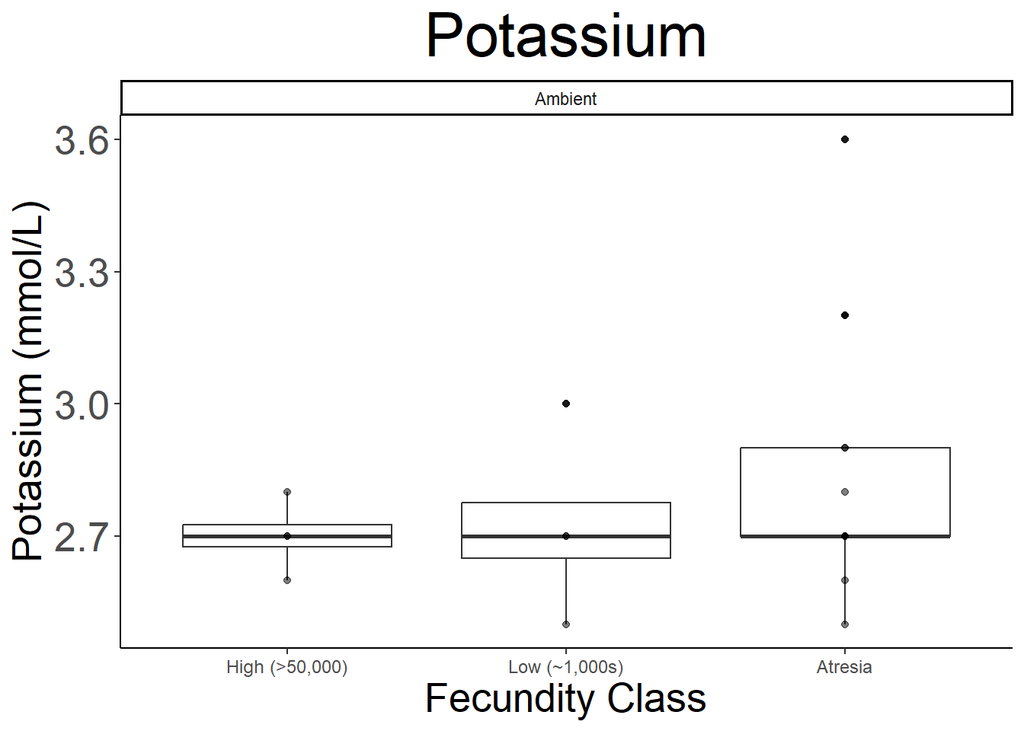

```r
# K+ boxplot

# Amb_Fec Samples with Atresia Ids
potassium_amb_fec_all_boxplot <- ggplot(data = Amb_Fec_Samples) +
  geom_boxplot(aes(x = Fecundity_Class, y = K...mmol.L.)) +
  geom_point(aes(x = Fecundity_Class, y = K...mmol.L.), alpha = 0.5, colour = "black") +
  labs(title = "Potassium", x = "Fecundity Class", y = "Potassium (mmol/L)") +
   facet_wrap(~ Ambient.Or.OAH) +
  theme_classic() +
  theme(panel.background = element_rect(fill = "white"),
        plot.background = element_rect(fill = "white"),
        legend.background = element_rect(fill = "white", color = "black"),
        title = element_text(size = 12),
        plot.title = element_text(size = 30, hjust = 0.5),
        axis.text.x = element_text(size = 9),
        axis.text.y = element_text(size = 20),
        axis.title.x = element_text(size = 20),
        axis.title.y = element_text(size = 20))

print(potassium_amb_fec_all_boxplot)
```

```r
ggsave(filename = "data-images/potassium_amb_fec_all_boxplot.pdf", plot = potassium_amb_fec_all_boxplot, device = "pdf")
ggsave(filename = "data-images/potassium_amb_fec_boxplot.png", plot = potassium_amb_fec_all_boxplot, device = "png")
```

Potassium Parametric Assessment Data Distribution

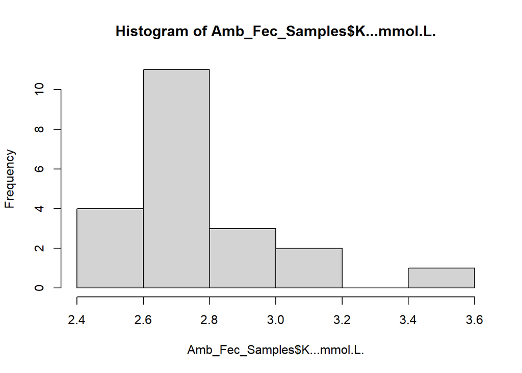

```r
# K+
# Parametric Assumptions

# Data Distribution


# Amb Fec Samples
# Frequency Histograms

hist(Amb_Fec_Samples$K...mmol.L.)
```

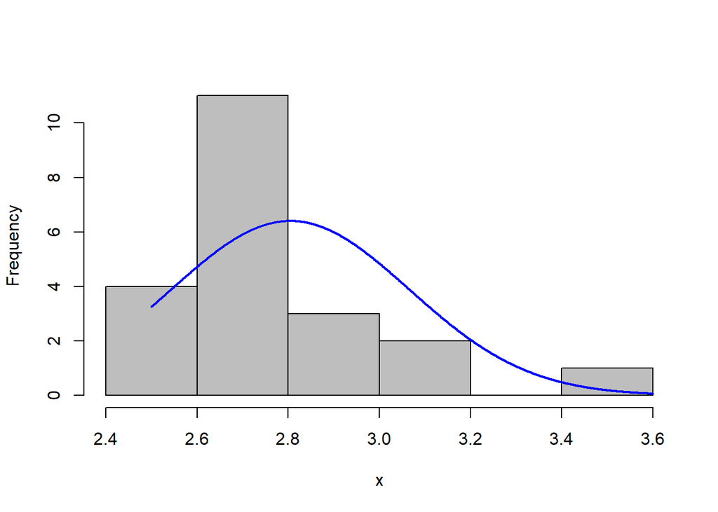

```r
plotNormalHistogram(Amb_Fec_Samples$K...mmol.L.)
```

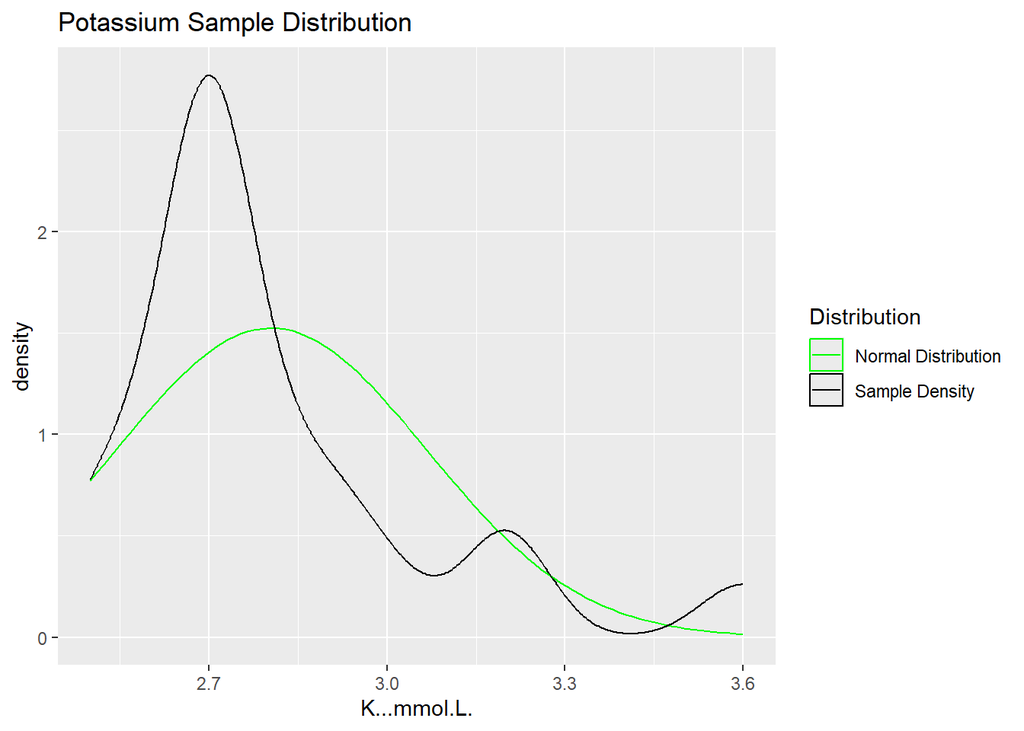

```r
# Density plot

Amb_Fec_Samples %>%
  ggplot(aes(x = K...mmol.L.)) +
  stat_function(fun = dnorm, args = c(mean = mean(Amb_Fec_Samples$K...mmol.L.), sd = sd(Amb_Fec_Samples$K...mmol.L.)), aes(col = "Normal Distribution"), show.legend = TRUE) +
  geom_density(aes(col = "Sample Density"), show.legend = TRUE) +
  labs(title = "Potassium Sample Distribution") +
  scale_color_manual("Distribution", values = c("Normal Distribution" = "green", "Sample Density" = "black"))
```

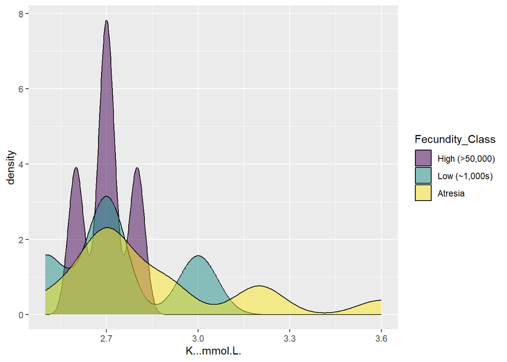

```r
# Density by brood condition
Amb_Fec_Samples %>%
ggplot(aes(x = K...mmol.L.)) +
  geom_density(aes(x = K...mmol.L., fill = Fecundity_Class), alpha = 0.5)
```

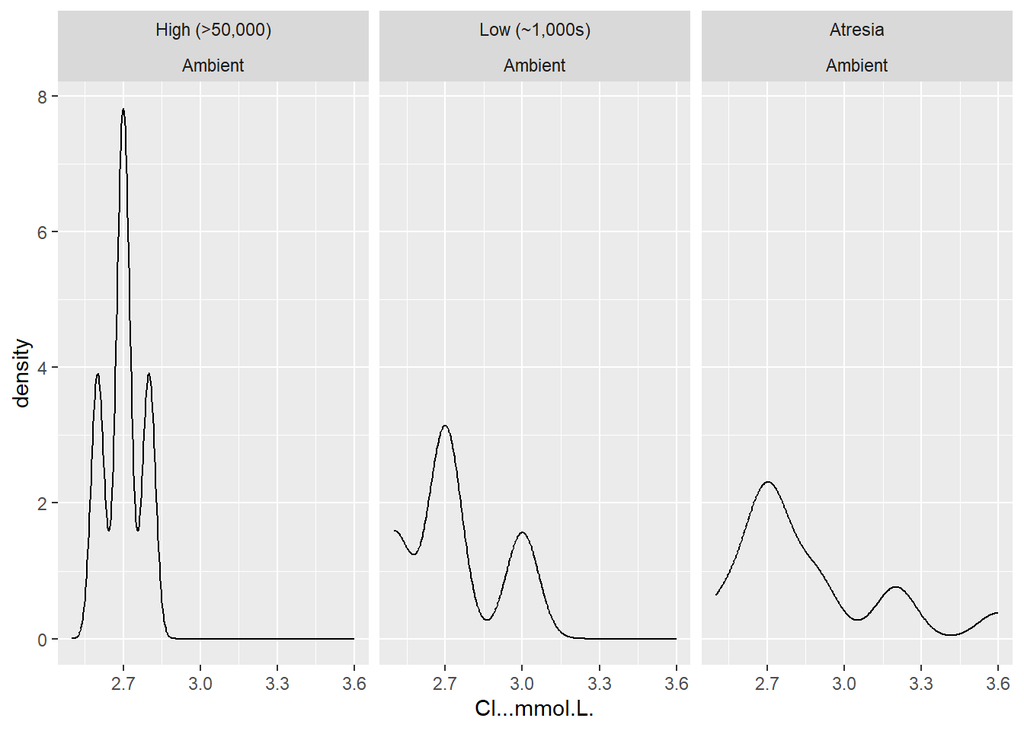

```r
ggplot(Amb_Fec_Samples, aes(x = Cl...mmol.L.)) +
  geom_density(aes(x = K...mmol.L.)) +
  facet_wrap(Fecundity_Class ~ Ambient.Or.OAH)
```

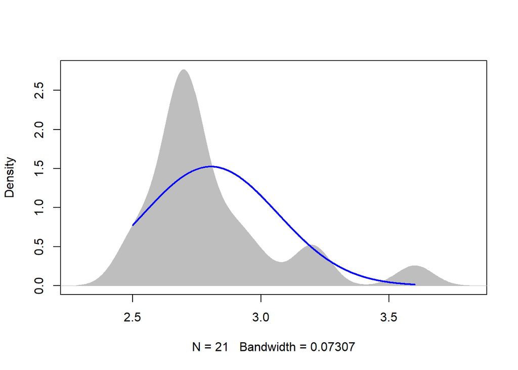

```r
plotNormalDensity(Amb_Fec_Samples$K...mmol.L.)
```

Test For Outliers

```r
# Test for Outliers
```

Model Design

```r
# Install flexplot
# devtools::install_github("dustinfife/flexplot", ref="development")
require(flexplot)

# Amb Fec regression model

potassium_amb_fec_lmer <- lmer(K...mmol.L. ~ All_Fecundity + (All_Fecundity | Fecundity_Class), data = Amb_Fec_Samples)
```

```
## boundary (singular) fit: see help('isSingular')
```

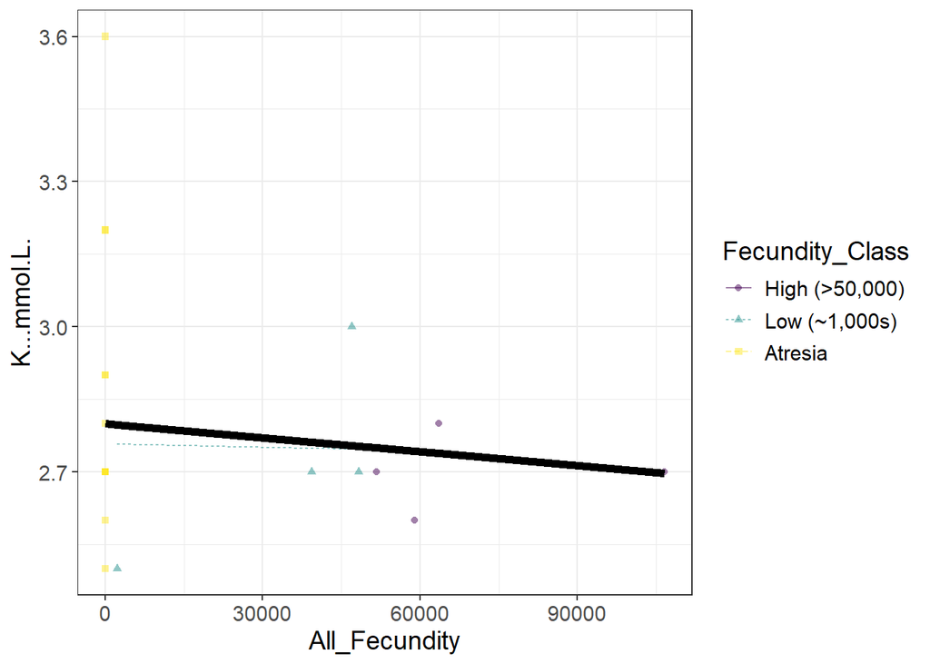

```r
visualize(potassium_amb_fec_lmer, plot = "model")
```

Potassium Parametric Assessment Testing Scedasticity:

```r
# K+

# Amb Fec samples

# test with lmer
bartlett.test(K...mmol.L. ~ Fecundity_Class, Amb_Fec_Samples)
```

```
##
##  Bartlett test of homogeneity of variances
##
## data:  K...mmol.L. by Fecundity_Class
## Bartlett's K-squared = 4.6368, df = 2, p-value = 0.09843
```

```r
# leveneTest()
```

Potassium Parametric Assumptions Assessment:

Warning: Check after assessing outliers

- Amb Fec Data normally distributed?
- Amb Fec Data equal variance across factors?

# K+ Stat Tests

# Ca+2 : Calcium

Calcium Summary Stats

```r
# Ca+2
# Summary stats

# Amb Fec data
Amb_Fec_Samples %>%
  group_by(Ambient.Or.OAH, Pregnant.Or.Atresia) %>%
  summarize(count = n(),
            median = round(median(Ca....mmol.L.), 3),
            mean = round(mean(Ca....mmol.L.), 3),
            sd = round(sd(Ca....mmol.L.), 3),
            cv = round(sd(Ca....mmol.L.)/mean(Ca....mmol.L.), 3)) %>%
  ungroup()
```

```
## # A tibble: 2 × 7
##   Ambient.Or.OAH Pregnant.Or.Atresia count median  mean    sd    cv
##   <chr>          <chr>               <int>  <dbl> <dbl> <dbl> <dbl>
## 1 Ambient        Atresia                13   1.24  1.27 0.114 0.09
## 2 Ambient        Post Parturition        8   1.43  1.43 0.041 0.029
```

```r
# Amb Fec Class data
Amb_Fec_Samples %>%
  group_by(Ambient.Or.OAH, Fecundity_Class) %>%
  summarize(count = n(),
            median = round(median(Ca....mmol.L.), 3),
            mean = round(mean(Ca....mmol.L.), 3),
            sd = round(sd(Ca....mmol.L.), 3),
            cv = round(sd(Ca....mmol.L.)/mean(Ca....mmol.L.), 3)) %>%
  ungroup()
```

```
## # A tibble: 3 × 7
##   Ambient.Or.OAH Fecundity_Class count median  mean    sd    cv
##   <chr>          <ord>           <int>  <dbl> <dbl> <dbl> <dbl>
## 1 Ambient        High (>50,000)      4   1.45  1.45 0.044 0.03
## 2 Ambient        Low (~1,000s)       4   1.41  1.41 0.033 0.023
## 3 Ambient        Atresia            13   1.24  1.27 0.114 0.09
```

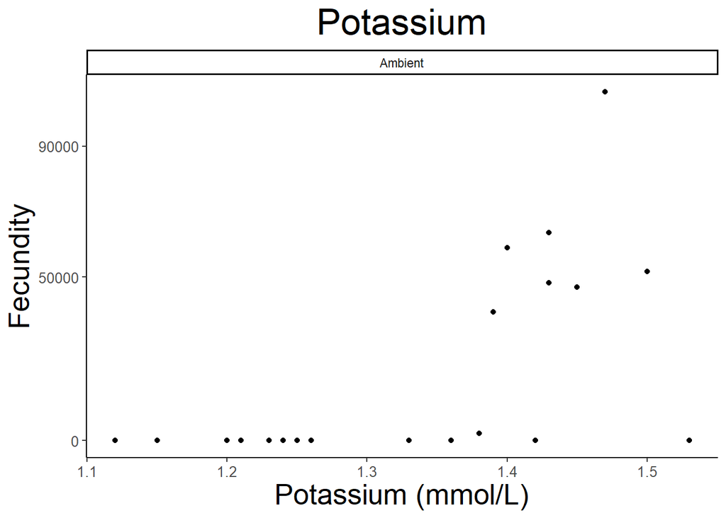

```r
# Ca+2 Scatterplot

# Amb_fec Samples:
# Note When using Fecundity_Or_Brood_Count col, the "No Parturition" aka atresia ids are automatically removed in plots, and results display numerical count, but this may cause issues if column is called in stat tests
# Refer to 'All_Fecundity' col (all numeric, includes atresia ids as 0)
# Refer to 'Fecundity_No_Atresia' col (all numeric, excludes atresia ids)
# Refer to 'Fecundity_Class' col for categorical classification of fecund data (Not 'Consensus_Fecundity' col, which is same, but raw data input)

# Amb Fec Count Samples : With atresia Ids
potassium_amb_fec_all_scatterplot <- ggplot(data = Amb_Fec_Samples) +
  geom_point(aes(x = Ca....mmol.L., y = All_Fecundity), colour = "black") +
  labs(title = "Potassium", x = "Potassium (mmol/L)", y = "Fecundity") +
  scale_y_continuous(breaks = c(0, 50000, 90000)) +
  facet_wrap(~ Ambient.Or.OAH) +
  theme_classic() +
  theme(panel.background = element_rect(fill = "white"),
        plot.background = element_rect(fill = "white"),
        legend.background = element_rect(fill = "white", color = "black"),
        plot.title = element_text(size = 25, hjust = 0.5),
        axis.text.x = element_text(size = 10),
        axis.text.y = element_text(size = 10),
        axis.title.x = element_text(size = 20),
        axis.title.y = element_text(size = 20))

print(potassium_amb_fec_all_scatterplot)
```

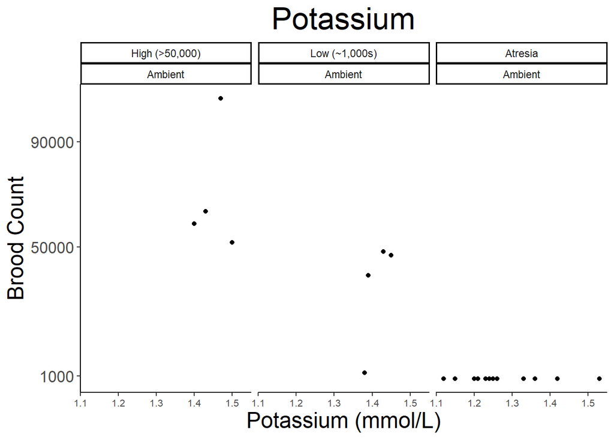

```r
ggsave(filename = "data-images/potassium_amb_fec_all_scatterplot.pdf", plot = potassium_amb_fec_all_scatterplot, device = "pdf")
ggsave(filename = "data-images/potassium_amb_fec_all_scatterplot.png", plot = potassium_amb_fec_all_scatterplot, device = "png")
# pH Amb Fec Count facet scatterplot by Fecundity Class
potassium_amb_fec_all_facet_scatterplot_fecundity_class <- ggplot(data = Amb_Fec_Samples) +
  geom_point(aes(x = Ca....mmol.L., y = All_Fecundity), colour = "black") +
  labs(title = "Potassium", x = "Potassium (mmol/L)", y = "Brood Count") +
  scale_y_continuous(breaks = c(1000, 50000, 90000)) +
  facet_wrap(Fecundity_Class ~ Ambient.Or.OAH) +
  theme_classic() +
  theme(panel.background = element_rect(fill = "white"),
        plot.background = element_rect(fill = "white"),
        legend.background = element_rect(fill = "white", color = "black"),
        plot.title = element_text(size = 25, hjust = 0.5),
        axis.text.x = element_text(size = 8),
        axis.text.y = element_text(size = 13),
        axis.title.x = element_text(size = 18),
        axis.title.y = element_text(size = 18))

print(potassium_amb_fec_all_facet_scatterplot_fecundity_class)
```

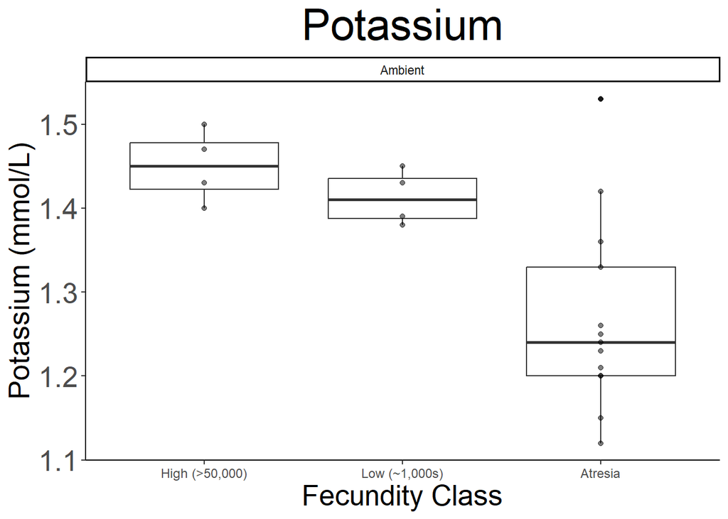

```r
# Ca+2 boxplot

# Amb_Fec Samples with Atresia Ids
potassium_amb_fec_boxplot <- ggplot(data = Amb_Fec_Samples) +
  geom_boxplot(aes(x = Fecundity_Class, y = Ca....mmol.L.)) +
  geom_point(aes(x = Fecundity_Class, y = Ca....mmol.L.), alpha = 0.5, colour = "black") +
  labs(title = "Potassium", x = "Fecundity Class", y = "Potassium (mmol/L)") +
   facet_wrap(~ Ambient.Or.OAH) +
  theme_classic() +
  theme(panel.background = element_rect(fill = "white"),
        plot.background = element_rect(fill = "white"),
        legend.background = element_rect(fill = "white", color = "black"),
        title = element_text(size = 12),
        plot.title = element_text(size = 30, hjust = 0.5),
        axis.text.x = element_text(size = 9),
        axis.text.y = element_text(size = 20),
        axis.title.x = element_text(size = 20),
        axis.title.y = element_text(size = 20))

print(potassium_amb_fec_boxplot)
```

```r
ggsave(filename = "data-images/potassium_amb_fec_boxplot.pdf", plot = potassium_amb_fec_boxplot, device = "pdf")
ggsave(filename = "data-images/potassium_amb_fec_boxplot.png", plot = potassium_amb_fec_boxplot, device = "png")
```

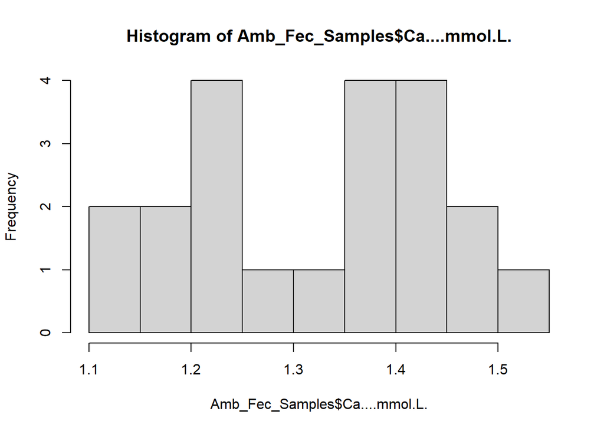

```r
# Ca+2
# Parametric Assumptions

# Data Distribution


# Amb Fec Samples
# Frequency Histograms

hist(Amb_Fec_Samples$Ca....mmol.L.)
```

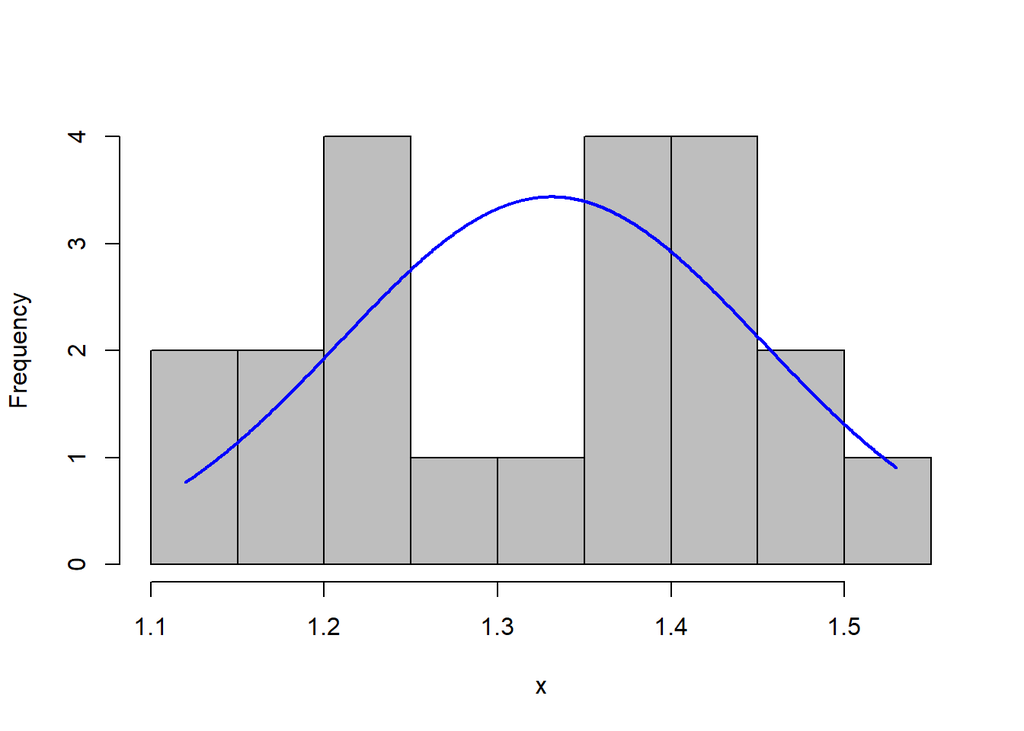

```r
plotNormalHistogram(Amb_Fec_Samples$Ca....mmol.L.)
```

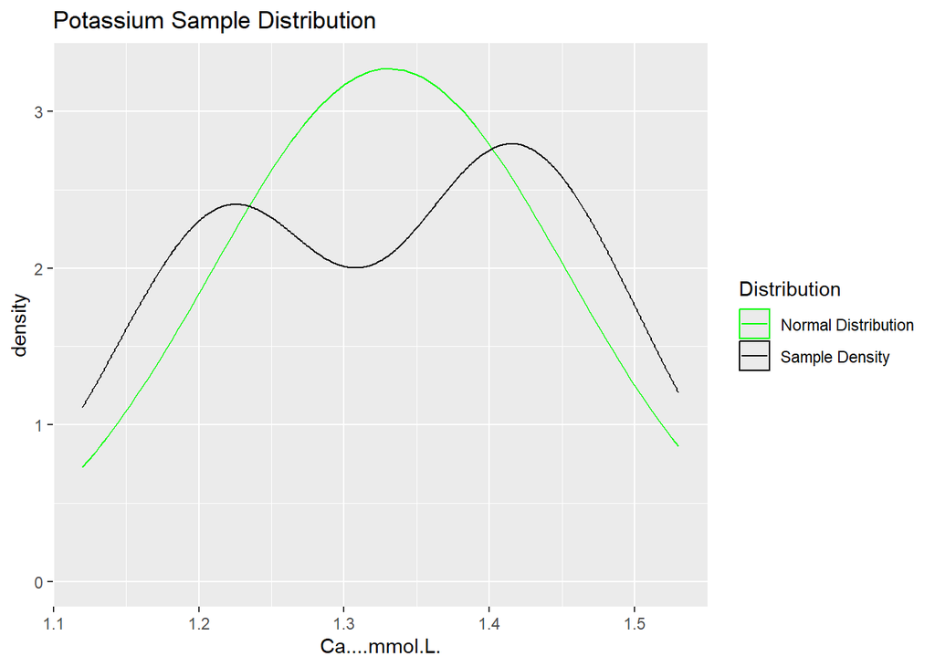

```r
# Density plot

Amb_Fec_Samples %>%
  ggplot(aes(x = Ca....mmol.L.)) +
  stat_function(fun = dnorm, args = c(mean = mean(Amb_Fec_Samples$Ca....mmol.L.), sd = sd(Amb_Fec_Samples$Ca....mmol.L.)), aes(col = "Normal Distribution"), show.legend = TRUE) +
  geom_density(aes(col = "Sample Density"), show.legend = TRUE) +
  labs(title = "Potassium Sample Distribution") +
  scale_color_manual("Distribution", values = c("Normal Distribution" = "green", "Sample Density" = "black"))
```

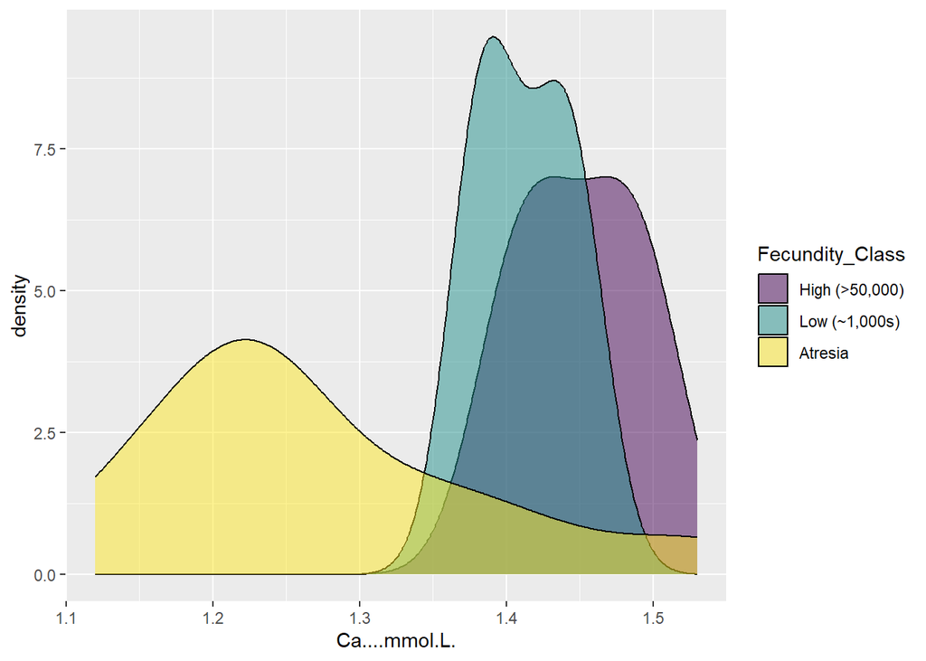

```r
# Density by brood condition
Amb_Fec_Samples %>%
ggplot(aes(x = Ca....mmol.L.)) +
  geom_density(aes(x = Ca....mmol.L., fill = Fecundity_Class), alpha = 0.5)
```

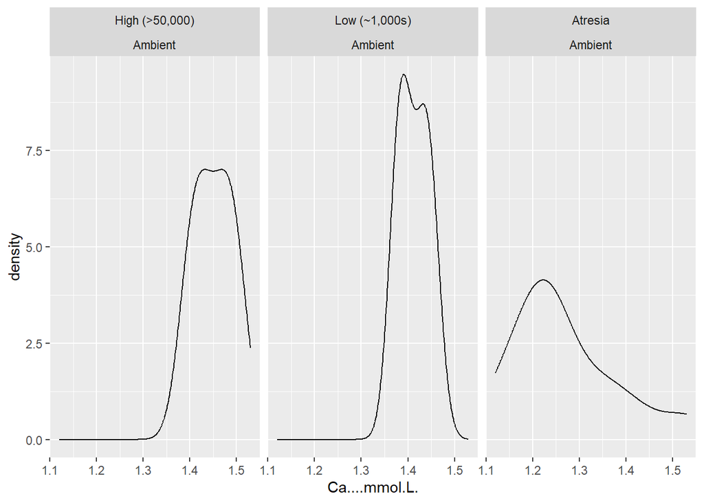

```r
ggplot(Amb_Fec_Samples, aes(x = Ca....mmol.L.)) +
  geom_density(aes(x = Ca....mmol.L.)) +
  facet_wrap(Fecundity_Class ~ Ambient.Or.OAH)
```

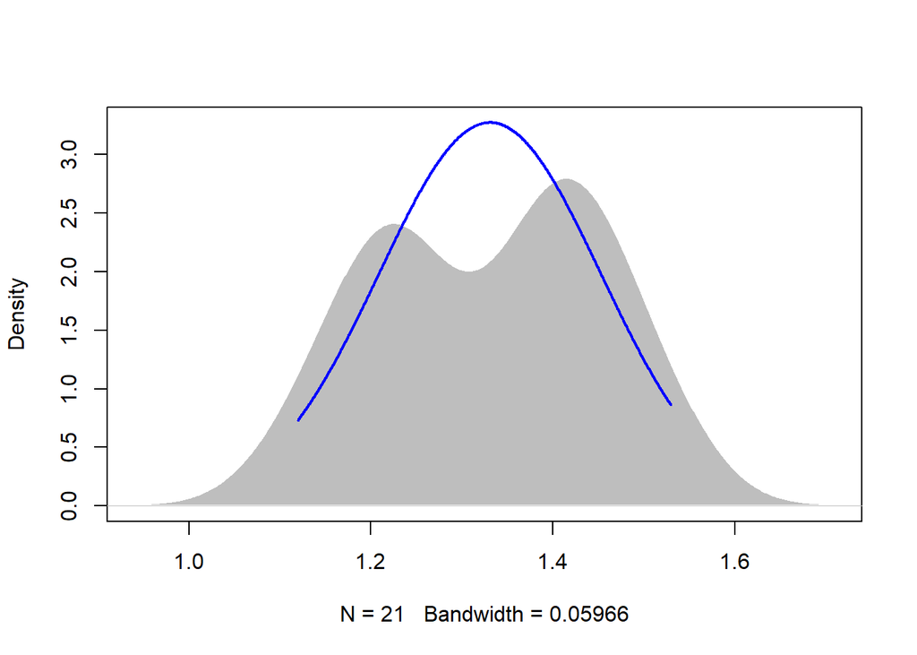

```r
plotNormalDensity(Amb_Fec_Samples$Ca....mmol.L.)
```

Test For Outliers

```r
# Test for Outliers
```

Model Design

```r
# Install flexplot
# devtools::install_github("dustinfife/flexplot", ref="development")
require(flexplot)

# Amb Fec regression model

potassium_amb_fec_lmer <- lmer(Ca....mmol.L. ~ All_Fecundity + (All_Fecundity | Fecundity_Class), data = Amb_Fec_Samples)
```

```
## boundary (singular) fit: see help('isSingular')
```

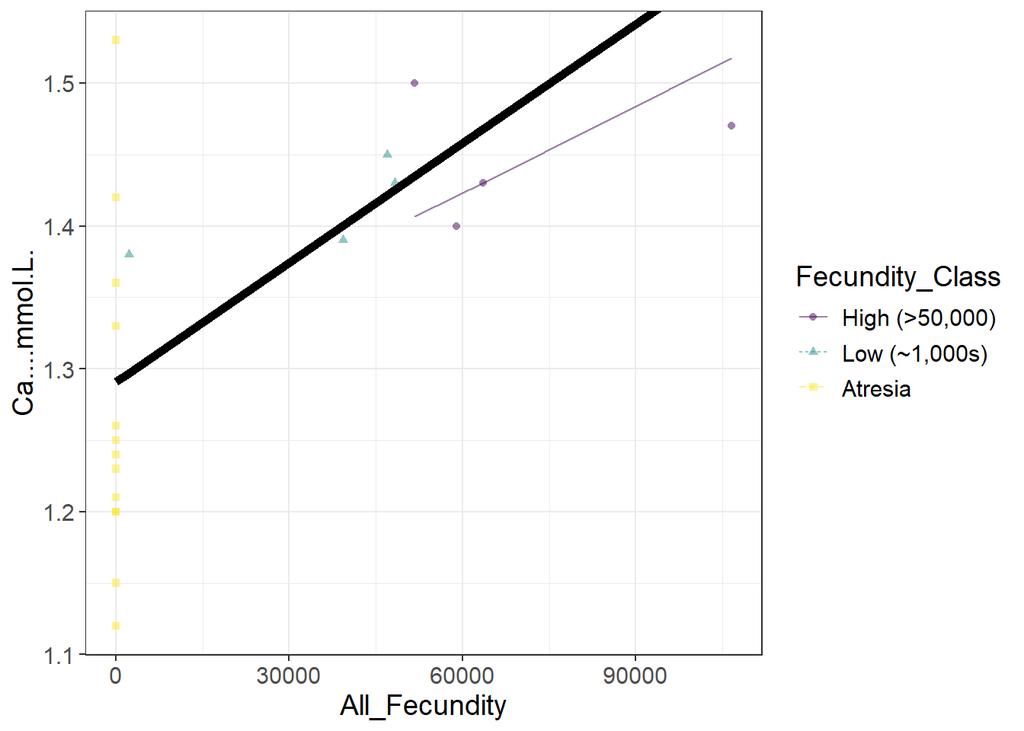

```r
visualize(potassium_amb_fec_lmer, plot = "model")
```

Calcium Parametric Assessment Testing Scedasticity:

```r
# Ca+2

# Amb Fec samples

# test with lmer
bartlett.test(Ca....mmol.L. ~ Fecundity_Class, Amb_Fec_Samples)
```

```
##
##  Bartlett test of homogeneity of variances
##
## data:  Ca....mmol.L. by Fecundity_Class
## Bartlett's K-squared = 6.1296, df = 2, p-value = 0.04666
```

```r
# leveneTest()
```

Calcium Parametric Assumptions Assessment:

Warning: Check after assessing outliers

- Amb Fec Data normally distributed?
- Amb Fec Data equal variance across factors?

# Ca+2 Stat Tests